# Manuscript draft

### Introduction

Globally, forests play an important role in the carbon cycle. Old growth forests alone are estimated to sequester up to 1.4 GtCyr <sup>-1</sup> (Y. Malhi, Baldocchi, & Jarvis, 1999), making them a significant carbon sink, and an important component of global carbon dioxide budgets (Luyssaert et al., 2008). Understanding the patterns and mechanisms of forest carbon cycling on a global scale is therefore of high importance in understanding the potential role of forests in mitigating climate change.

It is understood that the productivity of forests shows variation with latitude, with a general trend of increasing productivity towards the tropics; however the exact nature of this pattern and the mechanisms that drive it are poorly understood. Climate can be an important driver of productivity, particularly on a global scale; achieving a better understanding of the climatic controls on forest productivity will help to illuminate potential responses and feedbacks of forests to climate change.

In order to better understand and predict responses and feedbacks to climate change, we need a better fundamental understand of how forest carbon cycling varies with respect to climate globally.

*Patterns of primary productivity.* Understanding variation in primary productivity is complex. Firstly, there are many factors which can influence productivity on a range of scales, many of which show interactive effects with each other. In addition, the primary productivity of a forest is the sum of the primary productivity of a number of individual components, which may all show individual responses to drivers of productivity. Understanding these relationships and interdependencies is complex.

*Understanding components of primary productivity.* There are several different measures of primary productivity. Gross primary productivity (GPP) represents the gross uptake of carbon dioxide by plants in an ecosystem, to be used in photosynthesis and energy production. Only a fraction of this carbon is assimilated into plant tissues; the rest is used in autotrophic respiration. The component of GPP that is stored as plant material is the net primary productivity (NPP) of an ecosystem; thus GPP can be described as the sum of NPP and ecosystem respiration.

Currently, GPP cannot be measured directly by observing total ecosystem photosynthesis. Instead field estimates of GPP have to be derived based on modelling and extrapolation of eddy-covariance studies and measurements of net ecosystem exchange (NEE) (Clark et al., 2017).

NPP is typically measured through direct measurements of the productivity of its components, which are then summed to generate a whole-ecosystem estimate. These components can be broadly divided into aboveground NPP (ANPP) and belowground NPP (BNPP). Measurement of aboveground NPP - primarily consisting of woody stem, woody branch and canopy/foliage primary productivity, but also sometimes including estimates of productivity of reproductive and understory components, and losses due to herbivory - is most commonly estimated through forest plot censuses. Belowground NPP is significantly more challenging to measure, meaning that estimates of belowground productivity are less reliable than those of aboveground productivity. Coarse root productivity is typically determined by using allometric equations relating root mass to stem diameter. This relies on extrapolation of ANPP measures, rather than being based on direct measures of root productivity. Fine root productivity is estimated using a variety of methods, such as taking soil cores and minirhizotrons, making it typically more reliable than measures of coarse root productivity.

Current knowledge indicates that these different components of productivity show different latitudinal patterns. Gross primary productivity is generally thought to be highest in the tropics. Modelling of global terrestrial ecosystem GPP though upscaling and calibration of eddy flux measurements indicates a peak in GPP in the tropics, with the highest levels in tropical forests (C. Beer et al., 2010; Jung et al., 2011). This is corroborated by analysis of site-level GPP measurements, which show a strong positive correlation between GPP and mean annual temperature (MAT) and mean annual precipitation (MAP) (Luyssaert et al., 2007), with the highest GPP values reported in tropical forests. The influence of latitude on global patterns of NPP is less clear than that of GPP. Simova and Storch (2017) found that, as with GPP, NPP decreases with latitude, peaking in the tropics. However, other studies have found the highest values of NPP in temperate forests (Huston & Wolverton, 2009; Luyssaert et al., 2007). Because of the challenges in accurately obtaining unbiased measures of belowground productivity, many studies focus on ANPP in preference to measures of NPP. Studies on global patterns of ANPP are equally inconclusive: Gillman et al. (2015) found a weak negative relationship between ANPP and latitude, with the relationship becoming stronger in older forest stands. These findings were echoed in other studies, which have found weak or no relationships between ANPP and latitude (Huston & Wolverton, 2009).

These variations in the responses of different components of productivity to changes in latitude suggest that components may vary in the strength of their response to climatic drivers. There is some empirical evidence for this: increases in GPP are reported to saturate above 25$^\circ$C MAT (Larjavaara & Muller-Landau, 2012), while increases in NPP are recorded to saturate above 10$^\circ$C MAT (Luyssaert et al., 2007). Similarly, allocation to different components of ANPP varies with climate. Within the tropics, allocation to canopy NPP appears fairly consistent, with significantly greater variation in allocation to woody and belowground NPP (Litton et al., 2007; Y. Malhi, Doughty, & Galbraith, 2011). Allocation to these structural biomass components has been shown to increase with water availability (Bloom, Exbrayat, Velde, Feng, & Williams, 2016; Litton et al., 2007), and is highest in the wet tropics, indicating that control of woody productivity by MAP may be more significant than control of foliar productivity. However, these studies are regional, meaning that our understanding of variation in allocation and its relationship to climate on a global scale remains limited.

Allocation is also influenced by stand age (De Lucia, Drake, Thomas, & Gonzalez-Meler, 2007), nutrient availability (Litton et al., 2007) and forest structure (Taylor et al., 2019), which can make it challenging to disentangle the effects of climate.

Data that control for stand age and standardize methodologies are required to resolve this question. Here, we use a comprehensive global database to explore global patterns in productivity.

### Methods

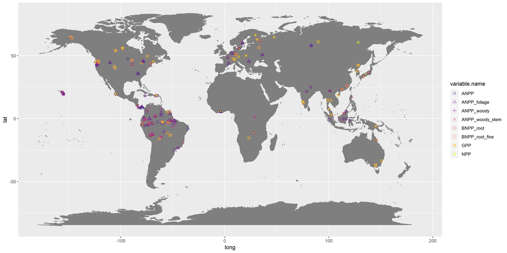

Figure 1: Map showing all data used in the anlysis, coded by variable

*Data selection.* ForC contains measures of carbon stocks and fluxes; for the purposes of this analysis only measures of primary productivity were selected from the database. The variables selected were: GPP, NPP, BNPP (total root and fine root), ANPP (total ANPP, foliage, wood and woody stem).

[output not shown]

Sites were excluded from analysis if they were managed, defined as plots that were planted, managed as plantations, irrigated, fertilised or including the term “managed” in their site description. Sites that had experienced significant disturbance were also excluded. Disturbances that justified site exclusion were major cutting or harvesting, and/or burning, flooding, drought and storm events with site mortality >10% of trees.  
There is evidence that stand age influences patterns of primary productivity and carbon allocation in forest ecosystems, and can confound relationships between latitude and primary productivity (De Lucia et al., 2007; Gillman et al., 2015). To reduce any biasing effects of stand age, stands under 100 years of age were excluded from analysis.

*Methodological consistency.* The data in ForC is derived from a range of studies, often employing different methods. For this reason, criteria were introduced to standardise for differences in methodology. Where data was based on forest plot census measurements, studies which uses a minimum dbh measure of 10cm or greater were excluded from analysis.  
Estimates of total ecosystem primary productivity are based on measurements of the component parts of forest productivity. Since the components included in productivity estimates vary between studies, estimates of productivity were classified within the ForC database according to their components, and then filtered for analysis. Estimates of NPP were selected if they included foliage, branch, stem, coarse root, fine root and understory. Measures of NPP which included additional components were excluded. Estimates of ANPP were selected if they included foliage, stem growth and branch turnover. Any measures of primary productivity where components were unknown were excluded from analysis.

*Climate datasets.* Where site-level data on mean annual temperature, mean annual precipitation, and latitude were available in the primary literature, this data was compiled and entered directly into the ForC database. In addition to this data, climate data for each site was extracted from five open-access climate datasets.

| Database | Variables downloaded | Citation |
| --- | --- | --- |
| WorldClim | Mean annual temperature; temperature seasonality; annual temperature range; mean annual precipitation | (Hijmans, Cameron, Parra, Jones, & Jarvis, 2005) |
| WorldClim2 | Vapour pressure; solar radiation | (Fick & Hijmans, 2017) |
| Climate Research Unit (CRU) time-series dataset v 4.03 | Cloud cover; annual frost days; annual wet days; potential evapotranspiration | (Harris, Jones, Osborn, & Lister, 2014) |
| Global Aridity Index and Potential Evapotranspiration Climate Database | Aridity; potential evapotranspiration | (Trabucco & Zomer, 2018) |
| TerraClimate | Vapour pressure deficit | (Abatzoglou, Dobrowski, Parks, & Hegewisch, 2018) |

### References

Abatzoglou, J. T., Dobrowski, S. Z., Parks, S. A., & Hegewisch, K. C. (2018). TerraClimate, a high-resolution global dataset of monthly climate and climatic water balance from 1958-2015. *Scientific Data*, *5*, 1–12. https://doi.org/10.1038/sdata.2017.191

Anderson-Teixeira, K. J., Wang, M. M., Mcgarvey, J. C., & Lebauer, D. S. (2016). Carbon dynamics of mature and regrowth tropical forests derived from a pantropical database (TropForC-db). *Global Change Biology*, *22*(5), 1690–1709. https://doi.org/10.1111/gcb.13226

Anderson-Teixeira, K. J., Wang, M. M., McGarvey, J. C., Herrmann, V., Tepley, A. J., Bond-Lamberty, B., & LeBauer, D. S. (2018). ForC: a global database of forest carbon stocks and fluxes. *Ecology*, *99*(6), 1507. https://doi.org/10.1002/ecy.2229

Beer, C., Reichstein, M., Tomelleri, E., Ciais, P., Jung, M., Carvalhais, N., … Papale, D. (2010). Terrestrial gross carbon dioxide uptake: Global distribution and covariation with climate. *Science*, *329*(5993), 834–838. https://doi.org/10.1126/science.1184984

Bloom, A. A., Exbrayat, J.-F., Velde, I. R. van der, Feng, L., & Williams, M. (2016). The decadal state of the terrestrial carbon cycle: Global retrievals of terrestrial carbon allocation, pools, and residence times. *Proceedings of the National Academy of Sciences*, *113*(5), 1285–1290. https://doi.org/10.1073/pnas.1515160113

Chu, C., Bartlett, M., Wang, Y., He, F., Weiner, J., Chave, J., & Sack, L. (2016). Does climate directly influence NPP globally? *Global Change Biology*, *22*(1), 12–24. https://doi.org/10.1111/gcb.13079

Clark, D. A., Asao, S., Fisher, R., Reed, S., Reich, P. B., Ryan, M. G., … Yang, X. (2017). Reviews and syntheses: Field data to benchmark the carbon cycle models for tropical forests. *Biogeosciences*, *14*(20), 4663–4690. https://doi.org/10.5194/bg-14-4663-2017

De Lucia, E. H., Drake, J. E., Thomas, R. B., & Gonzalez-Meler, M. (2007). Forest carbon use efficiency: Is respiration a constant fraction of gross primary production? *Global Change Biology*, *13*(6), 1157–1167. https://doi.org/10.1111/j.1365-2486.2007.01365.x

Fick, S. E., & Hijmans, R. J. (2017). WorldClim 2: new 1-km spatial resolution climate surfaces for global land areas. *International Journal of Climatology*, *37*(12), 4302–4315. https://doi.org/10.1002/joc.5086

Gillman, L. N., Wright, S. D., Cusens, J., Mcbride, P. D., Malhi, Y., & Whittaker, R. J. (2015). Latitude, productivity and species richness. *Global Ecology and Biogeography*, *24*(1), 107–117. https://doi.org/10.1111/geb.12245

Girardin, C. A. J., Malhi, Y., Aragão, L. E., Mamani, M., Huaraca Huasco, W., Durand, L., … Whittaker, R. J. (2010). Net primary productivity allocation and cycling of carbon along a tropical forest elevational transect in the Peruvian Andes. *Global Change Biology*, *16*(12), 3176–3192. https://doi.org/10.1111/j.1365-2486.2010.02235.x

Harris, I., Jones, P. D., Osborn, T. J., & Lister, D. H. (2014). Updated high-resolution grids of monthly climatic observations - the CRU TS3.10 Dataset. *International Journal of Climatology*, *34*(3), 623–642. https://doi.org/10.1002/joc.3711

Hijmans, R. J., Cameron, S. E., Parra, J. L., Jones, P. G., & Jarvis, A. (2005). Very high resolution interpolated climate surfaces for global land areas. *International Journal of Climatology*, *25*(15), 1965–1978. https://doi.org/10.1002/joc.1276

Huston, M. A., & Wolverton, S. (2009). The global distribution of net primary production: resolving the paradox. *Ecological Monographs*, *79*(3), 343–377.

Jung, M., Reichstein, M., Margolis, H. A., Cescatti, A., Richardson, A. D., Arain, M. A., … Williams, C. (2011). Global patterns of land-atmosphere fluxes of carbon dioxide, latent heat, and sensible heat derived from eddy covariance, satellite, and meteorological observations. *Journal of Geophysical Research: Biogeosciences*, *116*(3), 1–16. https://doi.org/10.1029/2010JG001566

Kerkhoff, A. J., Enquist, B. J., Elser, J. J., & Fagan, W. F. (2005). Plant allometry, stoichiometry and the temperature-dependence of primary productivity. *Global Ecology and Biogeography*, *14*(6), 585–598. https://doi.org/10.1111/j.1466-822X.2005.00187.x

Larjavaara, M., & Muller-Landau, H. C. (2012). Temperature explains global variation in biomass among humid old-growth forests. *Global Ecology and Biogeography*, *21*(10), 998–1006. https://doi.org/10.1111/j.1466-8238.2011.00740.x

Litton, C. M., Raich, J. W., & Ryan, M. G. (2007). Carbon allocation in forest ecosystems. *Global Change Biology*, *13*(10), 2089–2109. https://doi.org/10.1111/j.1365-2486.2007.01420.x

Luyssaert, S., Inglima, I., Jung, M., Richardson, A. D., Reichstein, M., Papale, D., … Janssens, I. A. (2007). CO2 balance of boreal, temperate, and tropical forests derived from a global database. *Global Change Biology*, *13*(12), 2509–2537. https://doi.org/10.1111/j.1365-2486.2007.01439.x

Luyssaert, S., Schulze, E. D., Börner, A., Knohl, A., Hessenmöller, D., Law, B. E., … Grace, J. (2008). Old-growth forests as global carbon sinks. *Nature*, *455*(7210), 213–215. https://doi.org/10.1038/nature07276

Malhi, Y. (2012). The productivity, metabolism and carbon cycle of tropical forest vegetation. *Journal of Ecology*, *100*(1), 65–75. https://doi.org/10.1111/j.1365-2745.2011.01916.x

Malhi, Y., Baldocchi, D. D., & Jarvis, P. G. (1999). *The carbon balance of tropical, temperate and boreal forests*. 715–740.

Malhi, Y., Doughty, C., & Galbraith, D. (2011). The allocation of ecosystem net primary productivity in tropical forests. *Philosophical Transactions of the Royal Society B: Biological Sciences*, *366*(1582), 3225–3245. https://doi.org/10.1098/rstb.2011.0062

Malhi, Y., Girardin, C. A., Goldsmith, G. R., Doughty, C. E., Salinas, N., Metcalfe, D. B., … Silman, M. (2017). The variation of productivity and its allocation along a tropical elevation gradient: a whole carbon budget perspective. *New Phytologist*, *214*(3), 1019–1032. https://doi.org/10.1111/nph.14189

Michaletz, S. T., Cheng, D., Kerkhoff, A. J., & Enquist, B. J. (2014). Convergence of terrestrial plant production across global climate gradients. *Nature*, *512*(1), 39–43. https://doi.org/10.1038/nature13470

Michaletz, S. T., Kerkhoff, A. J., & Enquist, B. J. (2018). Drivers of terrestrial plant production across broad geographical gradients. *Global Ecology and Biogeography*, *27*(2), 166–174. https://doi.org/10.1111/geb.12685

Šímová, I., & Storch, D. (2017). The enigma of terrestrial primary productivity: measurements, models, scales and the diversity–productivity relationship. *Ecography*, *40*(2), 239–252. https://doi.org/10.1111/ecog.02482

Taylor, P. G., Cleveland, C. C., Soper, F., Wieder, W. R., Dobrowski, S. Z., Doughty, C. E., & Townsend, A. R. (2019). Greater stem growth, woody allocation, and aboveground biomass in Paleotropical forests than in Neotropical forests. *Ecology*, *100*(3), 1–9. https://doi.org/10.1002/ecy.2589

Trabucco, A., & Zomer, R. J. (2018). Global Aridity Index and Potential Evapotranspiration (ET0) Climate Database v2. *CGIAR Consortium for Spatial Information (CGIAR-CSI)*, (November), 10. https://doi.org/10.6084/m9.figshare.7504448.v3